# 13 Playground – Interactions cat cat treatment coded

```r
library(tidyverse)
library(interactions)
```

# data set-up

```r
set.seed(1)
anx <- read_csv("https://uoepsy.github.io/data/lmm_ef_sdmt.csv") |>
  slice_sample(prop = .6) |>
  rename(
   anx = SDMT,
  ) |>
  mutate(
    transport = ifelse(headphones == 'H', 'Cyclist', 'Motorist'),
    road_type  = case_when(
      audio == 'music' ~ 'RuralRoad',
      audio == 'no_audio' ~ 'CityStreet',
      audio == 'white_noise' ~ 'DualCarriageway'
    )
  ) |>
  select(anx, transport, road_type) |>
  rownames_to_column(var = 'ppt_id')

# write_csv(anx, '../../data/post_travel_anx.csv')
# write_csv(anx, '../data/post_travel_anx.csv')
```

```r
anx <- read_csv('../../data/post_travel_anx.csv')
```

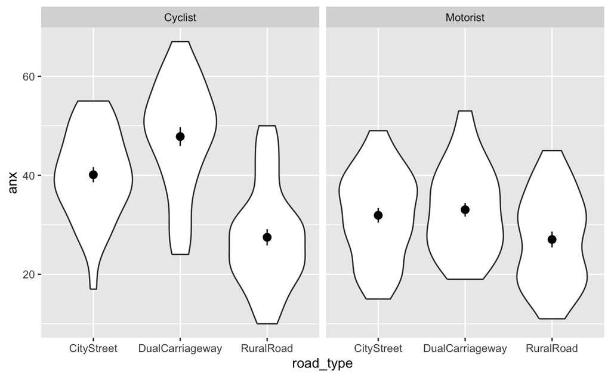

```r
anx |>
  ggplot(aes(x = road_type, y = anx)) +
  geom_violin() +
  stat_summary(geom = 'pointrange') +
  facet_wrap(~ transport)
```

# 2x2 data treatment coded

```r
anx1 <- filter(
  anx,
  road_type %in% c('CityStreet', 'RuralRoad')
)
```

## violin plots (symmetrical)

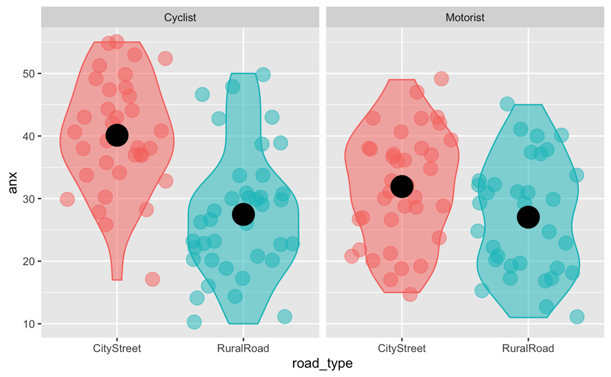

```r
anx1 |>
  ggplot(aes(x = road_type, y = anx, colour = road_type, fill = road_type)) +
  geom_violin(alpha = 0.5) +
  geom_jitter(alpha = 0.5, size = 5) +
  stat_summary(fun = mean, geom = 'point', colour = 'black', size = 8) +
  facet_wrap(~ transport) +
  theme(legend.position = 'none') +
  NULL
```

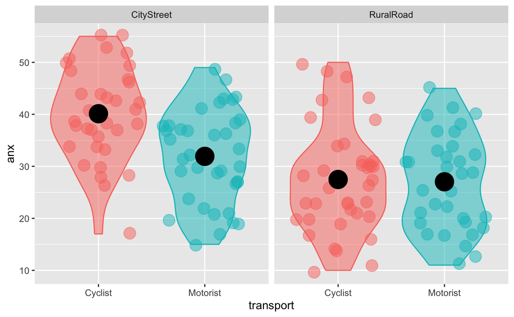

```r
anx1 |>
  ggplot(aes(x = transport, y = anx, colour = transport, fill = transport)) +
  geom_violin(alpha = 0.5) +
  geom_jitter(alpha = 0.5, size = 5) +
  stat_summary(fun = mean, geom = 'point', colour = 'black', size = 8) +
  facet_wrap(~ road_type) +
  theme(legend.position = 'none') +
  NULL
```

TODO: add diff of diffs into plot as vertical line between means, at x = 1.5 in each facet.

## pointrange plots

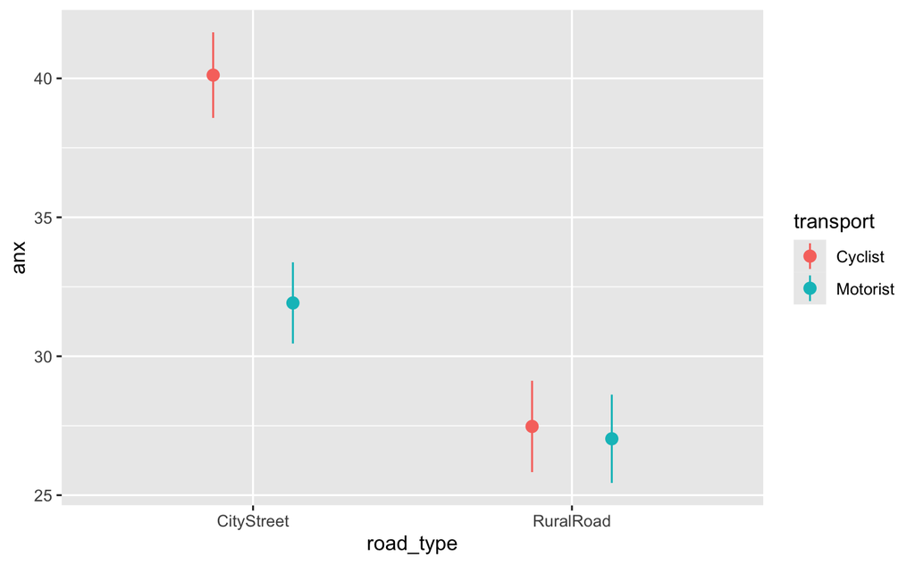

```r
anx1 |>
  ggplot(aes(x = road_type, y = anx, colour = transport)) +
  stat_summary(geom = 'pointrange', position = position_dodge(width = .5)) +
  NULL
```

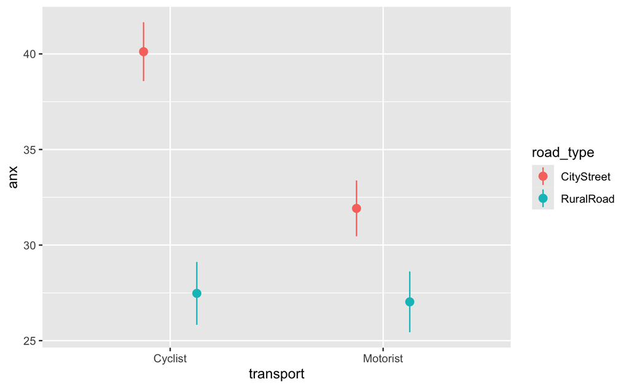

```r
anx1 |>
  ggplot(aes(x = transport, y = anx, colour = road_type)) +
  stat_summary(geom = 'pointrange', position = position_dodge(width = .5)) +
  NULL
```

## set up data

Set ref levels to the group that has the lower scores, so we can measure how anx increases in diff scenarios.

```r
anx1 <- anx1 |>
  mutate(
    transport = factor(transport, levels = c('Motorist', 'Cyclist')),
    road_type = factor(road_type, levels = c('RuralRoad', 'CityStreet'))
  )
```

```r
contrasts(anx1$transport)
```

```
         Cyclist
Motorist       0
Cyclist        1
```

```r
contrasts(anx1$road_type)
```

```
           CityStreet
RuralRoad           0
CityStreet          1
```

### contrast coding the interaction

| transport | road_type |
| --- | --- |
| Motorist | Rural |
| Motorist | City |
| Cyclist | Rural |
| Cyclist | City |

| transport | road_type |
| --- | --- |
| 0 | 0 |
| 0 | 1 |
| 1 | 0 |
| 1 | 1 |

| transport | road_type | transport:road_type |
| --- | --- | --- |
| 0 | 0 | 0 |
| 0 | 1 | 0 |
| 1 | 0 | 0 |
| 1 | 1 | 1 |

## fit the model

$$\text{anx} = \beta_0 +
(\beta_1 \cdot \text{transport}) +
(\beta_2 \cdot \text{road_type}) +
(\beta_3 \cdot \text{transport} \cdot \text{road_type}) +
\epsilon$$

```r
m1 <- lm(anx ~ transport * road_type, data = anx1)
summary(m1)
```

```
Call:
lm(formula = anx ~ transport * road_type, data = anx1)

Residuals:
     Min       1Q   Median       3Q      Max
-23.1176  -7.0303  -0.1963   6.0811  22.5263

Coefficients:
                                     Estimate Std. Error
(Intercept)                           27.0303     1.6213
transportCyclist                       0.4434     2.2162
road_typeCityStreet                    4.8886     2.2300
transportCyclist:road_typeCityStreet   7.7553     3.1316
                                     t value Pr(>|t|)
(Intercept)                           16.672   <2e-16 ***
transportCyclist                       0.200   0.8417
road_typeCityStreet                    2.192   0.0300 *
transportCyclist:road_typeCityStreet   2.476   0.0145 *
---
Signif. codes:
0 ‘***’ 0.001 ‘**’ 0.01 ‘*’ 0.05 ‘.’ 0.1 ‘ ’ 1

Residual standard error: 9.314 on 138 degrees of freedom
Multiple R-squared:  0.2413,    Adjusted R-squared:  0.2248
F-statistic: 14.63 on 3 and 138 DF,  p-value: 2.52e-08
```

## cat_plots

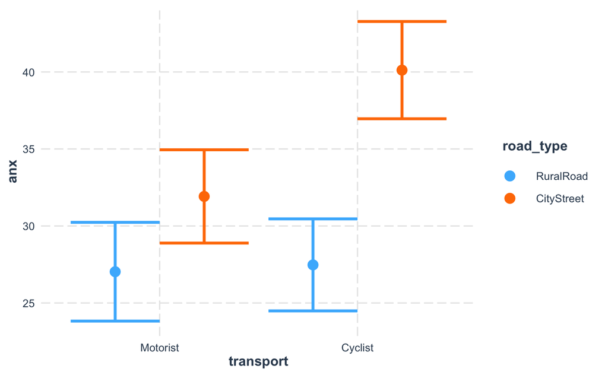

```r
cat_plot(
  m1,
  pred = transport,
  modx = road_type,
  # geom = 'line'
)
```

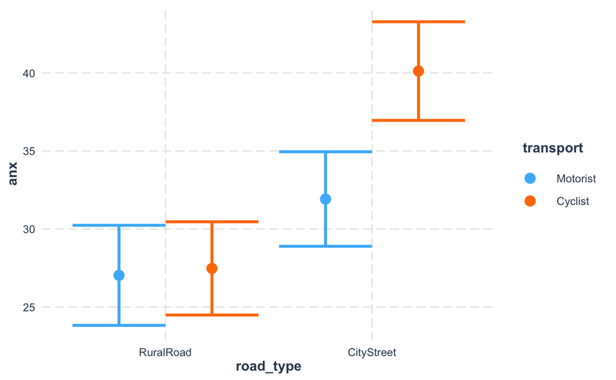

```r
cat_plot(
  m1,
  pred = road_type,
  modx = transport,
  # geom = 'line'
)
```

## simple effects by hand

(simple slopes = continuous, simple effects = categorical)

```r
coef(m1) |> round(2)
```

```
                         (Intercept)
                               27.03
                    transportCyclist
                                0.44
                 road_typeCityStreet
                                4.89
transportCyclist:road_typeCityStreet
                                7.76
```

### RuralRoad

$$\text{anx}_{\text{Rural}} = 27.03 + (0.44 \cdot \text{transport})
+ (4.89 \cdot 0) + (7.76 \cdot \text{transport} \cdot 0) + \epsilon
\\
\text{anx}_{\text{Rural}} = 27.03 + (0.44 \cdot \text{transport}) +
\epsilon \\$$

### CityStreet

$$\text{anx}_{\text{City}} = 27.03 + (0.44 \cdot \text{transport})
+ (4.89 \cdot 1) + (7.76 \cdot \text{transport} \cdot 1) + \epsilon
\\
\text{anx}_{\text{City}} = 27.03 + 4.89 + (0.44 \cdot \text{transport})
+ (7.76 \cdot \text{transport}) + \epsilon \\
\text{anx}_{\text{City}} = 31.92 + ((0.44 + 7.76) \cdot
\text{transport}) + \epsilon \\
\text{anx}_{\text{City}} = 31.92 + (8.2 \cdot \text{transport})
+ \epsilon \\$$

### Motorist

$$\text{anx}_{\text{Motorist}} = 27.03 + (0.44 \cdot 0) + (4.89 \cdot
\text{road_type}) + (7.76 \cdot 0 \cdot \text{road_type}) + \epsilon
\\
\text{anx}_{\text{Motorist}} = 27.03 + (4.89 \cdot \text{road_type}) +
\epsilon \\$$

### Cyclist

$$\text{anx}_{\text{Cyclist}} = 27.03 + (0.44 \cdot 1) + (4.89 \cdot
\text{road_type}) + (7.76 \cdot 1 \cdot \text{road_type}) + \epsilon
\\
\text{anx}_{\text{Cyclist}} = 27.03 + 0.44 + (4.89 \cdot
\text{road_type}) + (7.76 \cdot \text{road_type}) + \epsilon \\
\text{anx}_{\text{Cyclist}} = 27.47 + ((4.89 + 7.76) \cdot
\text{road_type}) + \epsilon \\
\text{anx}_{\text{Cyclist}} = 27.47 + (12.65 \cdot
\text{road_type}) + \epsilon \\$$

# 2x3 data treatment coded

```r
anx2 <- anx
```

## set up the data

```r
anx2 <- anx2 |>
  mutate(
    transport = factor(transport, levels = c('Motorist', 'Cyclist')),
    road_type = factor(road_type, levels = c('RuralRoad', 'CityStreet', 'DualCarriageway')),
  )
anx2
```

| ppt_id | anx | transport | road_type |
| --- | --- | --- | --- |
| 1 | 39 | Cyclist | RuralRoad |
| 2 | 41 | Cyclist | CityStreet |
| 3 | 38 | Motorist | RuralRoad |
| 4 | 63 | Cyclist | DualCarriageway |
| 5 | 18 | Motorist | RuralRoad |
| 6 | 47 | Cyclist | DualCarriageway |
| 7 | 25 | Motorist | RuralRoad |
| 8 | 29 | Motorist | CityStreet |
| 9 | 33 | Motorist | DualCarriageway |
| 10 | 38 | Cyclist | CityStreet |

[output cut: 206 more lines]

```r
contrasts(anx2$transport)
```

```
         Cyclist
Motorist       0
Cyclist        1
```

```r
contrasts(anx2$road_type)
```

```
                CityStreet DualCarriageway
RuralRoad                0               0
CityStreet               1               0
DualCarriageway          0               1
```

### contrast coding CityStreet ixn

| transport | road_type |
| --- | --- |
| Motorist | Rural |
| Motorist | City |
| Motorist | Dual |
| Cyclist | Rural |
| Cyclist | City |
| Cyclist | Dual |

| transport | road_typeCityStreet |
| --- | --- |
| 0 | 0 |
| 0 | 1 |
| 0 | 0 |
| 1 | 0 |
| 1 | 1 |
| 1 | 0 |

| transport | road_typeCityStreet | transport:road_typeCityStreet |
| --- | --- | --- |
| 0 | 0 | 0 |
| 0 | 1 | 0 |
| 0 | 0 | 0 |
| 1 | 0 | 0 |
| 1 | 1 | 1 |
| 1 | 0 | 0 |

### contrast coding DualCarriageway ixn

| transport | road_type |
| --- | --- |
| Motorist | Rural |
| Motorist | City |
| Motorist | Dual |
| Cyclist | Rural |
| Cyclist | City |
| Cyclist | Dual |

| transport | road_typeDualCarriageway |
| --- | --- |
| 0 | 0 |
| 0 | 0 |
| 0 | 1 |
| 1 | 0 |
| 1 | 0 |
| 1 | 1 |

| transport | road_typeDualCarriageway | transport:road_typeDualCarriageway |
| --- | --- | --- |
| 0 | 0 | 0 |
| 0 | 0 | 0 |
| 0 | 1 | 0 |
| 1 | 0 | 0 |
| 1 | 0 | 0 |
| 1 | 1 | 1 |

## fit the model

$$\text{anx} = \beta_0 +
(\beta_1 \cdot \text{transport}) +
(\beta_2 \cdot \text{road_type}_{\text{CS}}) +
(\beta_2 \cdot \text{road_type}_{\text{DC}}) + \\
(\beta_3 \cdot \text{transport} \cdot \text{road_type}_{\text{CS}}) +
(\beta_3 \cdot \text{transport} \cdot \text{road_type}_{\text{DC}}) +
\epsilon$$

```r
m2 <- lm(anx ~ transport * road_type, data = anx2)
summary(m2)
```

```
Call:
lm(formula = anx ~ transport * road_type, data = anx2)

Residuals:
     Min       1Q   Median       3Q      Max
-23.8235  -7.0303   0.3514   6.1765  22.5263

Coefficients:
                                          Estimate
(Intercept)                                27.0303
transportCyclist                            0.4434
road_typeCityStreet                         4.8886
road_typeDualCarriageway                    6.0197
transportCyclist:road_typeCityStreet        7.7553
transportCyclist:road_typeDualCarriageway  14.3301
                                          Std. Error
(Intercept)                                   1.6584
transportCyclist                              2.2669
road_typeCityStreet                           2.2811
road_typeDualCarriageway                      2.2404
transportCyclist:road_typeCityStreet          3.2033
transportCyclist:road_typeDualCarriageway     3.1744
                                          t value Pr(>|t|)
(Intercept)                                16.299  < 2e-16
transportCyclist                            0.196  0.84512
road_typeCityStreet                         2.143  0.03325
road_typeDualCarriageway                    2.687  0.00779
transportCyclist:road_typeCityStreet        2.421  0.01633
transportCyclist:road_typeDualCarriageway   4.514 1.06e-05

(Intercept)                               ***
transportCyclist
road_typeCityStreet                       *
road_typeDualCarriageway                  **
transportCyclist:road_typeCityStreet      *
transportCyclist:road_typeDualCarriageway ***
---
Signif. codes:
0 ‘***’ 0.001 ‘**’ 0.01 ‘*’ 0.05 ‘.’ 0.1 ‘ ’ 1

Residual standard error: 9.527 on 210 degrees of freedom
Multiple R-squared:  0.3692,    Adjusted R-squared:  0.3542
F-statistic: 24.58 on 5 and 210 DF,  p-value: < 2.2e-16
```

## cat_plots

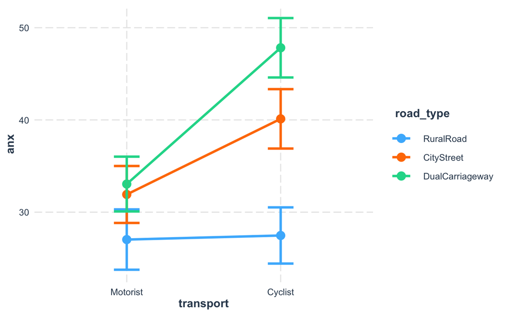

```r
cat_plot(
  m2,
  pred = transport,
  modx = road_type,
  geom = 'line'
)
```

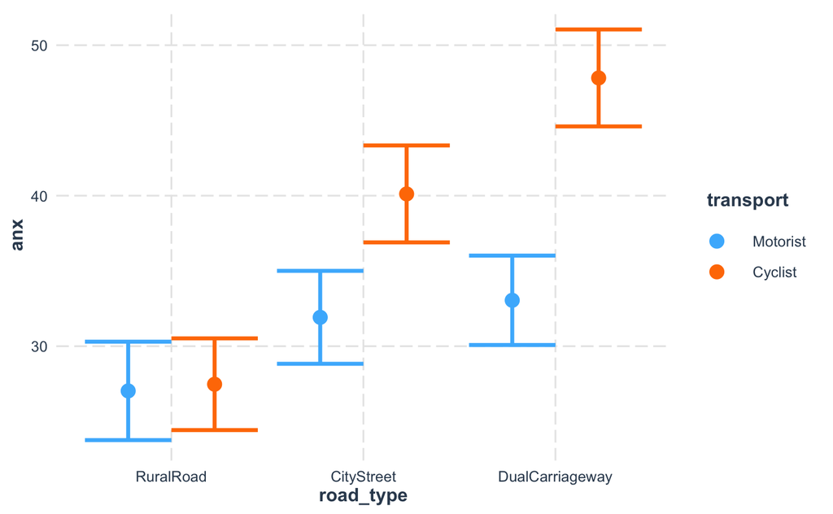

```r
cat_plot(
  m2,
  pred = road_type,
  modx = transport,
  # geom = 'line'
)
```

## simple effects by hand

### RuralRoad

To get RuralRoad, we have $\text{road_type}_{\text{CS}} = 0$ and $\text{road_type}_{\text{DC}} = 0$. (We know this bc of the contrast coding)

$$
$$\begin{align}
\text{anx}_{\text{RR}} ~=&~ \beta_0 + (\beta_1 \cdot
\text{transport}) + (\beta_2 \cdot \text{road_type}_{\text{CS}})
+ (\beta_3 \cdot \text{road_type}_{\text{DC}}) +
\\ & (\beta_4 \cdot \text{transport} \cdot
\text{road_type}_{\text{CS}}) + (\beta_5 \cdot \text{transport} \cdot
\text{road_type}_{\text{DC}}) + \epsilon \\
\text{anx}_{\text{RR}} ~=&~ \beta_0 + (\beta_1 \cdot
\text{transport}) + (\beta_2 \cdot 0) + (\beta_3 \cdot 0) +
\\ & (\beta_4 \cdot \text{transport} \cdot 0) + (\beta_5 \cdot
\text{transport} \cdot 0) + \epsilon \\
\text{anx}_{\text{RR}} ~=&~ \beta_0 + (\beta_1 \cdot
\text{transport}) + \epsilon \\
\end{align}$$
$$

### DualCarriageway

To get DualCarriageway, we have $\text{road_type}_{\text{CS}} = 0$ and $\text{road_type}_{\text{DC}} = 1$. (We know this bc of the contrast coding)

$$
$$\begin{align}
\text{anx}_{\text{DC}} ~=&~ \beta_0 + (\beta_1 \cdot
\text{transport}) + (\beta_2 \cdot \text{road_type}_{\text{CS}})
+ (\beta_3 \cdot \text{road_type}_{\text{DC}}) +
\\ & (\beta_4 \cdot \text{transport} \cdot
\text{road_type}_{\text{CS}}) + (\beta_5 \cdot \text{transport} \cdot
\text{road_type}_{\text{DC}}) + \epsilon \\
\text{anx}_{\text{DC}} ~=&~ \beta_0 + (\beta_1 \cdot
\text{transport}) + (\beta_2 \cdot 0) + (\beta_3 \cdot 1) +
\\ & (\beta_4 \cdot \text{transport} \cdot 0) + (\beta_5 \cdot
\text{transport} \cdot 1) + \epsilon \\
\text{anx}_{\text{DC}} ~=&~ \beta_0 + \beta_3 + ((\beta_1 + \beta_5)
\cdot \text{transport}) + \epsilon \\
\end{align}$$
$$

### Motorist

To get Motorist, we set transport = 0.

$$
$$\begin{align}
\text{anx}_{\text{Motorist}} ~=&~ \beta_0 + (\beta_1 \cdot
\text{transport}) + (\beta_2 \cdot \text{road_type}_{\text{CS}})
+ (\beta_3 \cdot \text{road_type}_{\text{DC}}) +
\\ & (\beta_4 \cdot \text{transport} \cdot
\text{road_type}_{\text{CS}}) + (\beta_5 \cdot \text{transport} \cdot
\text{road_type}_{\text{DC}}) + \epsilon \\
\text{anx}_{\text{Motorist}} ~=&~ \beta_0 + (\beta_1 \cdot 0)
+ (\beta_2 \cdot \text{road_type}_{\text{CS}}) + (\beta_3 \cdot
\text{road_type}_{\text{DC}}) +
\\ & (\beta_4 \cdot 0 \cdot \text{road_type}_{\text{CS}})
+ (\beta_5 \cdot 0 \cdot \text{road_type}_{\text{DC}}) + \epsilon \\
\text{anx}_{\text{Motorist}} ~=&~ \beta_0 + (\beta_2 \cdot
\text{road_type}_{\text{CS}}) + (\beta_3 \cdot
\text{road_type}_{\text{DC}}) + \epsilon \\
\end{align}$$
$$

# Imagine 2x3x2

What if this pattern of results looks different in different countries?

Might compare Scotland (not that much bike infrastructure) to the Netherlands (lots of bike infrastructure).

Reasonable question but big pain to analyse/interpret.

Only way to really interpret is to visualise.

# 2x2 data sum coded

## contrast coding the interaction

```r
contrasts(anx1$transport) <- contr.sum(2)
contrasts(anx1$road_type) <- contr.sum(2)
```

```r
contrasts(anx1$transport)
```

```
         [,1]
Motorist    1
Cyclist    -1
```

```r
contrasts(anx1$road_type)
```

```
           [,1]
RuralRoad     1
CityStreet   -1
```

| transport | road_type |
| --- | --- |
| Motorist | Rural |
| Motorist | City |
| Cyclist | Rural |
| Cyclist | City |

| transport | road_type |
| --- | --- |
| 1 | 1 |
| 1 | -1 |
| -1 | 1 |
| -1 | -1 |

[output not shown]

## fit the model

```r
m3 <- lm(anx ~ transport * road_type, data = anx1)
summary(m3)
```

```
Call:
lm(formula = anx ~ transport * road_type, data = anx1)

Residuals:
     Min       1Q   Median       3Q      Max
-23.1176  -7.0303  -0.1963   6.0811  22.5263

Coefficients:
                      Estimate Std. Error t value Pr(>|t|)
(Intercept)            31.6351     0.7829  40.407  < 2e-16
transport1             -2.1605     0.7829  -2.760  0.00657
road_type1             -4.3831     0.7829  -5.599 1.13e-07
transport1:road_type1   1.9388     0.7829   2.476  0.01448

(Intercept)           ***
transport1            **
road_type1            ***
transport1:road_type1 *
---
Signif. codes:
0 ‘***’ 0.001 ‘**’ 0.01 ‘*’ 0.05 ‘.’ 0.1 ‘ ’ 1

Residual standard error: 9.314 on 138 degrees of freedom
Multiple R-squared:  0.2413,    Adjusted R-squared:  0.2248
F-statistic: 14.63 on 3 and 138 DF,  p-value: 2.52e-08
```

```r
anx1 |>
  group_by(transport, road_type) |>
  summarise(m = mean(anx))
```

| transport | road_type | m |
| --- | --- | --- |
| Motorist | RuralRoad | 27.03030 |
| Motorist | CityStreet | 31.91892 |
| Cyclist | RuralRoad | 27.47368 |
| Cyclist | CityStreet | 40.11765 |

Intercept is mean of means.

But not mean of anx straight up, bc groups have diff sizes!

```r
mean(anx1$anx)
```

```
[1] 31.55634
```

nice ref for interpreting sum contrasts in the flash cards: https://uoepsy.github.io/dapr2/2425/labs/1_b4_reading.html#categorical-x-categorical-example

# 2x3 data sum coded

maybe leave this for the appendix

## contrast coding the ixns

```r
contrasts(anx2$road_type)
```

```
                [,1] [,2]
RuralRoad          1    0
CityStreet         0    1
DualCarriageway   -1   -1
```

### contrast coding road_type1 (Rural = 1)

| transport | road_type |
| --- | --- |
| Motorist | Rural |
| Motorist | City |
| Motorist | Dual |
| Cyclist | Rural |
| Cyclist | City |
| Cyclist | Dual |

| transport | road_type1 |
| --- | --- |
| 1 | 1 |
| 1 | 0 |
| 1 | -1 |
| -1 | 1 |
| -1 | 0 |
| -1 | -1 |

| transport | road_type1 | transport:road_type1 |
| --- | --- | --- |
| 1 | 1 | 1 |
| 1 | 0 | 0 |
| 1 | -1 | -1 |
| -1 | 1 | -1 |
| -1 | 0 | 0 |
| -1 | -1 | 1 |

### contrast coding road_type2 (City = 1)

| transport | road_type |
| --- | --- |
| Motorist | Rural |
| Motorist | City |
| Motorist | Dual |
| Cyclist | Rural |
| Cyclist | City |
| Cyclist | Dual |

| transport | road_type2 |
| --- | --- |
| 1 | 0 |
| 1 | 1 |
| 1 | -1 |
| -1 | 0 |
| -1 | 1 |
| -1 | -1 |

| transport | road_type2 | transport:road_type2 |
| --- | --- | --- |
| 1 | 0 | 0 |
| 1 | 1 | 1 |
| 1 | -1 | -1 |
| -1 | 0 | 0 |
| -1 | 1 | -1 |
| -1 | -1 | 1 |

## fit the model

```r
summary(m4)
```

```
Call:
lm(formula = anx ~ transport * road_type, data = anx2)

Residuals:
     Min       1Q   Median       3Q      Max
-23.8235  -7.0303   0.3514   6.1765  22.5263

Coefficients:
                            Estimate Std. Error t value
(Intercept)                  30.6664     0.9112  33.656
transportCyclist              7.8052     1.2996   6.006
road_type1                   -3.6361     1.3217  -2.751
road_type2                    1.2525     1.2837   0.976
transportCyclist:road_type1  -7.3618     1.8444  -3.991
transportCyclist:road_type2   0.3935     1.8429   0.214
                            Pr(>|t|)
(Intercept)                  < 2e-16 ***
transportCyclist            8.27e-09 ***
road_type1                   0.00646 **
road_type2                   0.33034
transportCyclist:road_type1 9.07e-05 ***
transportCyclist:road_type2  0.83112
---
Signif. codes:
0 ‘***’ 0.001 ‘**’ 0.01 ‘*’ 0.05 ‘.’ 0.1 ‘ ’ 1

Residual standard error: 9.527 on 210 degrees of freedom
Multiple R-squared:  0.3692,    Adjusted R-squared:  0.3542
F-statistic: 24.58 on 5 and 210 DF,  p-value: < 2.2e-16
```